# HOMEWORK 4

21210980006 黄悦欣

```r
library(dplyr)
library(ggplot2)
library(reshape)
library(tidyverse)
library(pROC)
```

### Task 1

Question: Write Newton-Raphson algorithm to estimate logistic regression by yourself.

1. Generate $X = (1, X_1, X_2, X_3)$, where $X_j ∼ N (0, I_N)$.
2. Set true parameter $\beta = (−1, 2, −3, 0.5)^{T}$.
3. Set $N = 200, 400, 800, 1600$.
4. Estimate $\beta$ using $NR$ algorithm for $R = 200$ times. For each $j$, draw $(\hat{\beta_j}^{(r)} − \beta_j)$ in boxplot for $N = 200, 400, 800, 1600$.

```r
NR <- function(N, beta = c(-1, 2, -3, 0.5), beta0 = c(0, 0, 0, 0)){

  R <- 200 # 重复次数
  beta_error <- c() # 记录估计值

  for (iter in 1:R) { # 重复R次NR Algorithm
    ## 根据真实beta生成N个样本
    set.seed(iter)
    X <- matrix(c(rep(1,N),rnorm(3*N, mean = 0, sd = 1)), nrow = N, byrow = FALSE) # 生成X
    p <- exp(X %*% beta)/(1+exp(X %*% beta)) # 真实p(x;beta)
    y <- sapply(p, function(x) rbinom(1, 1, x)) # 根据真实p(x;beta)生成Y

    ## Newton-Raphson Algorithm
    beta_old <- beta0 # 设定初始beta
    delta <- 1
    if (sum(delta) != 0) { # 迭代停止条件
      p_old <- exp(X %*% beta_old)/(1+exp(X %*% beta_old))
      W_old <- diag(as.numeric(p_old * (1-p_old)), nrow = N)
      beta_new <- beta_old + solve(t(X) %*% W_old %*% X) %*% t(X) %*% (y-p_old)
      delta <- beta_new - beta_old # 估计变化量
      beta_old <- beta_new
    }
    beta_error <- rbind(beta_error, as.numeric(beta_new - beta))
  }

  colnames(beta_error) <- c('beta0','beta1','beta2','beta3')
  return(beta_error)
}
```

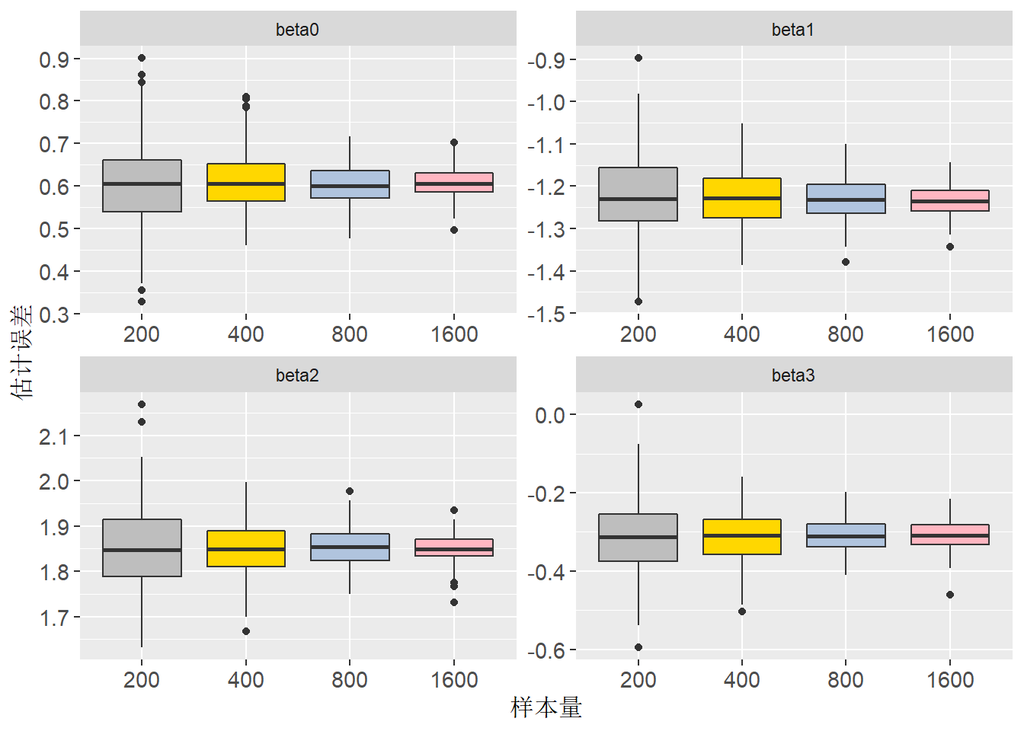

```r
beta_plot <- c()
N <- c(200, 400, 800, 1600)

for (n in N) {
  betaN <- NR(n) # Newton-Raphson algorithm, 样本量为n
  betaN <- melt(betaN, measure.vars = c('beta0','beta1','beta2','beta3')) # 短表变长表
  colnames(betaN) <- c('N','beta','error')
  betaN$N <- n
  beta_plot <- rbind(beta_plot, betaN)
}

ggplot(beta_plot) +
  geom_boxplot(aes(x = factor(N), y = error), fill = rep(c("grey","gold","lightsteelblue","lightpink"),4)) +
  labs(x="样本量", y = "估计误差") +
  facet_wrap(~beta,scales="free") +
  theme(panel.border=element_blank(),
        text = element_text(family = "STXihei"),
        axis.title = element_text(size = 12),
        axis.text = element_text(size = 11))
```

### Task 2

1. 读入数据：

1. 读入所有话题的分类属性D-cate.csv，命名为cate
2. 读入行家属性D-mentor.csv，命名为mentor
3. 读入话题属性D-topic.csv，命名为topic
4. 读入用户对话题做出的评价D-comment.csv，命名为comment

```r
cate <- read.csv("D-cate.csv", header = T, stringsAsFactors = F, fileEncoding = "UTF-8-BOM")
mentor <- read.csv("D-mentor.csv", header = T, stringsAsFactors = F, fileEncoding = "UTF-8-BOM")
topic <- read.csv("D-topic.csv", header = T, stringsAsFactors = F, fileEncoding = "UTF-8-BOM")
comment <- read.csv("D-comment.csv", header = T, stringsAsFactors = F, fileEncoding = "UTF-8-BOM")
```

2. 数据处理：

1. 将以下变量转化为因子型

```r
# 对mentor表中的行家接受率arating，设置高接受率、中接受率、其他共三个水平
mentor$arating[!mentor$arating %in% c("高接受率", "中接受率")] <- "其他"
unique(mentor$arating)
```

```
## [1] "其他"     "高接受率" "中接受率"
```

```r
# 对mentor表中的行家回应邀约时间react_tm，设置半天内回应、1天内回应、2天内回应、其他共四个水平
unique(mentor$react_tm)
```

```
## [1] "半天内回应" "1天内回应"  "其他"       "2天内回应"
```

```r
# 对topic表中的话题约见城市topic_city，设置北京、上海、深圳、广州、杭州、成都、武汉、西安、宁波、其他共10个水平
unique(topic$topic_city)
```

```
## [1] "北京" "杭州" "上海" "广州" "深圳" "成都" "宁波" "西安" "武汉"
```

2. 构造变量：

```r
# 在topic表中增加9个0-1变量：d1-d9，对应心理、投资理财、职场发展、教育学习、创业和融资、生活服务、互联网+、行业经验、其他共9个话题
d <- c("心理", "投资理财", "职场发展", "教育学习", "创业和融资", "生活服务", "互联网+", "行业经验", "其他")
topic_d <- matrix(0, ncol = 9, nrow = dim(topic)[1])
colnames(topic_d) <- paste('d',1:9,sep='')
for (i in 1:dim(topic)[1]) {
  topic_tag <- strsplit(topic$topic_tag[i],"^",fixed = T)[[1]]
  for (j in topic_tag) {
    topic_d[i,match(j,d)] <- 1
  }
}
topic <- cbind(topic,topic_d)

# 在topic中增加0-1变量：is_ord，话题是否成交（topic_ordcnt>0）
topic$is_ord <- ifelse(topic$topic_ordcnt >0, 1, 0)

# 在topic中增加0-1变量：is_fst，话题是否发生在北上深
topic$is_fst <- ifelse(topic$topic_city %in% c('北京','上海','深圳'), 1, 0)

# topic中增加话题价格带：price_b，分为<=300、(300,600]、(600,1000)、1000+四个水平
topic$price_b <- cut(topic$price, breaks = c(-Inf, 300, 600, 1000, Inf),
                     labels = c("<=300", "(300,600]", "(600,1000]", ">1000"))

# 对price_b因子化，并设定各取值的顺序
topic$price_b <- factor(topic$price_b, levels = c("<=300", "（300,600]", "(600,1000]", ">1000"))

# topic表中增加话题描述长度：len_desc，话题描述字符数，划分为(0,200]、(200,400]、(400,600]、(600,800]、(800,1000]、1000+六个水平
topic$len_desc_num <- sapply(topic$topic_desc, function(x) str_length(x))
topic$len_desc <- cut(topic$len_desc_num, breaks = c(0, 200, 400, 600, 800, 1000, Inf),
                      labels = c("(0,200]", "(200,400]", "(400,600]", "(600,800]", "(800,1000]", "1000+"))

# topic表中增加行家是否回复用户评价：is_rpl，行家是否回复用户评价（聚合comment表中is_reply得到reply_cnt，reply_cnt>0）
reply_cnt <-  aggregate(comment$is_reply, list(comment$topic_id, comment$mentor_id), sum)
colnames(reply_cnt) <- c("topic_id","mentor_id","reply_cnt")
topic <- merge(topic, reply_cnt,by = c("topic_id", "mentor_id"), all = TRUE)
topic$is_rpl <- ifelse(topic$reply_cnt >0, 1, 0)
```

3. 绘制导师约见人数分布直方图（可以考虑对mentor$mentor_ordcnt做对数变换），并进行描述分析

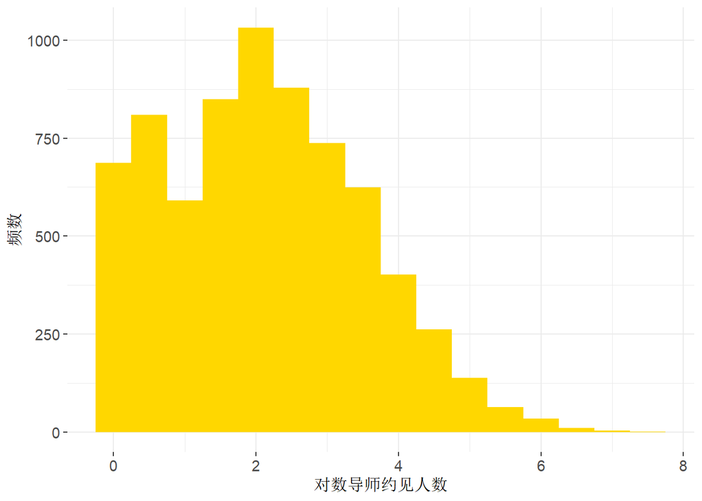

```r
log_mentor_ordcnt <- log(mentor$mentor_ordcnt)
log_mentor_ordcnt <- data.frame(log_mentor_ordcnt)

ggplot(log_mentor_ordcnt) +
    geom_histogram(aes(x = log_mentor_ordcnt), binwidth = 0.5, fill = "gold") +
    labs(y = "频数", x = "对数导师约见人数") +
    theme_bw() +
    theme(panel.border=element_blank(),
          text = element_text(family = "STXihei"),
          axis.title = element_text(size = 12),
          axis.text = element_text(size = 11))
```

根据对数导师约见人数直方图可以发现，

对数导师约见人数不服从正态分布，原始导师约见人数厚尾，部分导师拥有较高的受欢迎程度和自我包装意愿。

4. 分领域（心理、投资理财等共9个领域）绘制话题约见人数（topic_ordcnt）的箱线图，按中位数从左到右，从高到低的顺序排列，并进行描述分析

```r
topic_ordcnt <- topic[,c(paste('d',1:9,sep=''), "topic_ordcnt")]
topic_ordcnt <- data.frame(melt(topic_ordcnt, measure.vars = paste('d',1:9,sep=''))) # 短表变长表
colnames(topic_ordcnt) <- c('topic_ordcnt','topic_tag','value')
topic_ordcnt <- topic_ordcnt[topic_ordcnt$value == 1,] # 取出有话题标签的子集
topic_ordcnt <- rbind(topic_ordcnt,c(0, 'd5', 1)) # 补充“创业和融资”标签
topic_ordcnt$topic_ordcnt <- as.numeric(topic_ordcnt$topic_ordcnt)
topic_ordcnt$value <- as.numeric(topic_ordcnt$value)

# 按话题约见人数中位数排序
topic_tag <- topic_ordcnt %>%
  group_by(topic_tag) %>%
  summarise(median = median(topic_ordcnt))
topic_tag_level <- topic_tag$topic_tag[order(topic_tag$median, decreasing = T)]
topic_tag_label <- d[order(topic_tag$median, decreasing = T)]
# 替换话题标签名称，以便图形展示
topic_ordcnt$topic_tag <- factor(topic_ordcnt$topic_tag, levels = topic_tag_level, labels = topic_tag_label)
```

[output not shown]

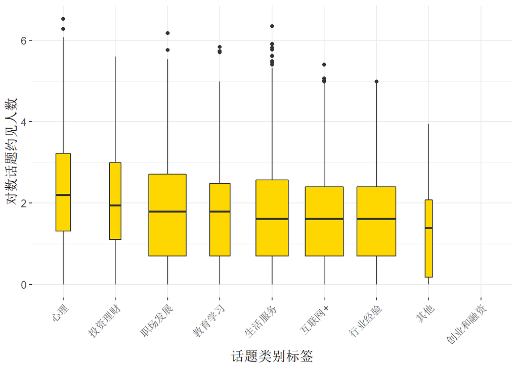

```r
ggplot(topic_ordcnt) +
  # 话题约见人数(topic_ordcnt)取对数
  geom_boxplot(aes(x = topic_tag, y = log(topic_ordcnt), fill = factor(value)), varwidth = TRUE) +
  labs(x = "话题类别标签", y = "对数话题约见人数") +
  scale_fill_manual(values = c("gold")) +
  theme_bw() +
  theme(panel.border=element_blank(),
        text = element_text(family = "STXihei"),
        axis.title = element_text(size = 13),
        axis.text = element_text(size = 10),
        legend.title = element_text(size = 10),
        axis.text.x = element_text(angle = 45,hjust = 1)) +
  guides(fill = FALSE)
```

**话题约见人数中位数方面**，心理和投资理财领域排名靠前，话题和行家约见热度高于其他，可能与话题本身属性相关，属于关注热门话题和专业大V的领域。

5. 绘制不同邀约接受率（arating）、不同响应时长（react_tm）、是否回复评价（is_rpl）和话题约见人数（topic_ordcnt）的箱线图，并进行描述分析

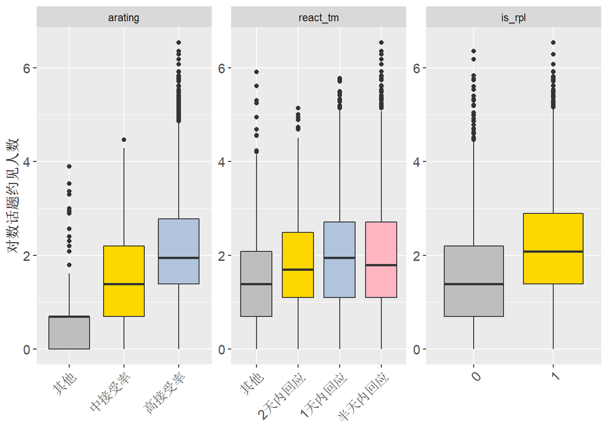

```r
topic_ordcnt <- topic[,c("topic_id","mentor_id","topic_ordcnt")]
# 邀约接受率
arating <- mentor[,c("mentor_id","arating")]
arating$arating <- factor(arating$arating, levels = c("其他", "中接受率", "高接受率"))
topic_ordcnt <- merge(topic_ordcnt, arating, by = "mentor_id")
# 响应时长
react_tm <- mentor[,c("mentor_id","react_tm")]
react_tm$react_tm <- factor(react_tm$react_tm, levels = c("其他", "2天内回应", "1天内回应", "半天内回应"))
topic_ordcnt <- merge(topic_ordcnt, react_tm, by = "mentor_id")
# 回复评价
is_rpl <- topic[,c("topic_id","mentor_id","is_rpl")]
is_rpl$is_rpl <- factor(is_rpl$is_rpl, levels = c("0","1"))
topic_ordcnt <- merge(topic_ordcnt, is_rpl, by = c("topic_id","mentor_id"))
# 删除缺失值
topic_ordcnt <- na.omit(topic_ordcnt)

topic_ordcnt_plot <- melt(topic_ordcnt, measure.vars = c("arating","react_tm","is_rpl")) # 短表变长表
topic_ordcnt_plot$Value <- rep(1,nrow(topic_ordcnt_plot))
colnames(topic_ordcnt_plot) <- c("topic_id","mentor_id","topic_ordcnt","Variable","X","Value")
level <- c("其他", "中接受率", "高接受率", "2天内回应", "1天内回应", "半天内回应", "0","1")
for (i in 1:length(level)) {
  value <- level[i]
  topic_ordcnt_plot$Value[topic_ordcnt_plot$X == value] <- i
}

ggplot(topic_ordcnt_plot) +
  geom_boxplot(aes(x = factor(X), y = log(topic_ordcnt), fill = factor(Value))) +
  labs(x = NULL, y = "对数话题约见人数") +
  scale_fill_manual(values = c("grey","gold","lightsteelblue","gold","lightsteelblue","lightpink","grey","gold")) +
  facet_wrap(~Variable,scales="free") +
  theme(panel.border=element_blank(),
        text = element_text(family = "STXihei"),
        axis.title = element_text(size = 12),
        axis.text = element_text(size = 11),
        axis.text.x = element_text(angle = 45,hjust = 1)) +
  guides(fill = FALSE)
```

**行家邀约接受率(arating)方面**，高接受率的行家约见人数更多。

**行家响应时长(react_tm)方面**，话题约见人数与行家回复邀约时长大致呈负相关关系，响应时长短的，约见人数更多；1天内回应的行家的话题约见人数中位数略高于半天内回应的行家，可能与待约见人数相关。

**是否回复评价(is_rpl)方面**，回复用户评价的行家，相较于从未与用户互动的行家，有更高的话题约见人数。

6. 根据comment表中信息，绘制各行业用户数量柱状图并进行描述分析

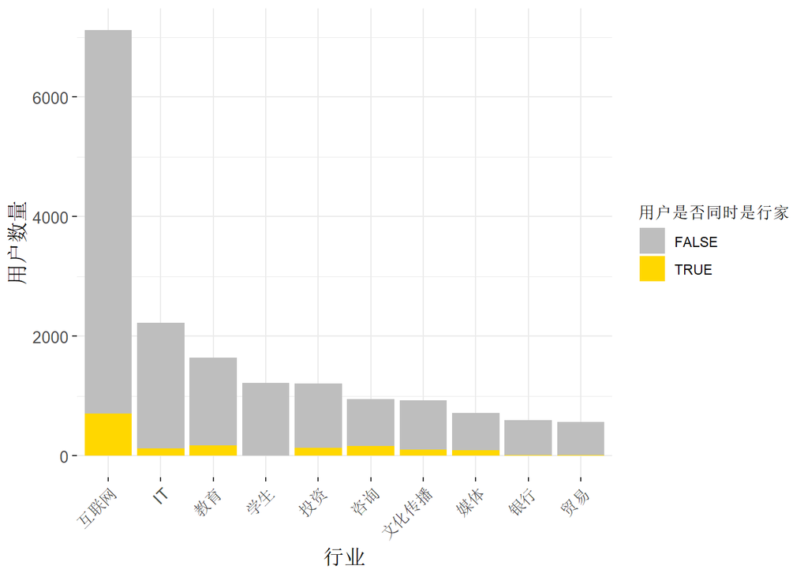

|  | 1 | 2 | 3 | 4 | 5 | 6 | 7 | 8 | 9 | 10 | 11 | 12 | 13 | 14 | 15 | 16 | 17 | 18 | 19 | 20 | 21 | 22 | 23 | 24 | 25 | 26 | 27 | 28 | 29 | … |
| --- | --- | --- | --- | --- | --- | --- | --- | --- | --- | --- | --- | --- | --- | --- | --- | --- | --- | --- | --- | --- | --- | --- | --- | --- | --- | --- | --- | --- | --- | --- |
| Var1 | 互联网 | 其他 | IT | 教育 | 学生 | 投资 | 咨询 | 文化传播 | 媒体 | 银行 | 贸易 | 医疗 | 设计 | 房地产 | 广告创意 | 酒店餐饮 | 机械制造 | 股票/基金 | 建筑 | 政府机关 | 通讯 | 能源 | 电子 | 影视 | 法律 | 旅游 | 生物医药 | 保险 | 个体经营 | … |
| Freq | 7122 | 2588 | 2222 | 1640 | 1216 | 1210 | 947 | 931 | 716 | 597 | 566 | 518 | 423 | 407 | 384 | 381 | 373 | 370 | 360 | 326 | 294 | 290 | 267 | 245 | 232 | 228 | 223 | 219 | 219 | … |

```r
## 用户数据
user <- comment[,c("user_id", "user_is_tutor", "user_industry_name")]
user <- user[!duplicated(user$user_id),]
user <- na.omit(user)

## 统计用户行业情况
industry_top <- as.data.frame(sort(table(user$user_industry_name), decreasing = T)[c(1,3:11)])
user_top10_industry <- user[user$user_industry_name %in% industry_top$Var1, ]
Top10_industry <- as.data.frame(table(user_top10_industry$user_industry_name,user_top10_industry$user_is_tutor))
colnames(Top10_industry) <- c("industry", "is_tutor", "number")

## 缩写名称，以便图形展示
Top10_industry$industry <- factor(Top10_industry$industry, levels = industry_top$Var1)

## 各行业用户数量柱状图
ggplot(Top10_industry) +
    geom_bar(aes(x = industry, y = number, fill = is_tutor),
             show.legend = T, stat = 'identity', position = 'stack') +
    labs(x = "行业", y = "用户数量", fill = "用户是否同时是行家") +
    scale_fill_manual(values = c("grey","gold")) +
    theme_bw() +
    theme(panel.border=element_blank(),
          text = element_text(family = "STXihei"),
          axis.title = element_text(size = 13),
          axis.text = element_text(size = 10),
          legend.title = element_text(size = 10),
          axis.text.x = element_text(angle = 45,hjust = 1))
```

```r
paste('行业数量:', length(unique(user$user_industry_name))-1)
```

```
## [1] "行业数量: 52"
```

```r
paste('前十大行业用户占比:', round(nrow(user_top10_industry)/nrow(user)*100,2), '%')
```

```
## [1] "前十大行业用户占比: 61.41 %"
```

根据comment表中已知行业信息，用户来自于52个不同行业，前十大行业用户占全部用户的61.41%，集中度高，并且从事互联网行业的用户数量以及用户中行家数量显著多于其他。

7. 使用is_ord作为因变量Y，自变量选择话题价格、话题价格带、想见行家用户数、行家约见人数、话题持续时长、话题所在城市、行家回复邀约的时长、行家接受约见的比率、话题长度、话题是否在北上广以及**???所属行业???**进行建模。使用AIC进行模型选择，绘制ROC曲线并计算AUC。

```r
DData <- topic[,c("topic_id", "mentor_id", "is_ord", "price", "price_b", "duration", "topic_city", "len_desc", "is_fst")]
heart <- mentor[,c("mentor_id", "heart", "mentor_ordcnt", "react_tm", "arating")]
DData <- merge(DData, heart, by = "mentor_id")
# industry <- comment[,c("topic_id", "mentor_id", "user_industry_name")]
# DData <- merge(DData, industry, by = c("topic_id", "mentor_id"))
DData <- na.omit(DData) # 删除缺失值
## 将哑变量能转换为factor类型
DData$is_ord <- as.factor(ifelse(DData$is_ord == 1, T, F))
# nominal <- c(5,6,7,8,9,12,13,14)
nominal <- c(5,6,7,8,9,12,13)
for (i in nominal){
  DData[,i] <- as.factor(DData[,i])
}

## 划分训练集和测试集
set.seed(123)
nsample <- sample(x = dim(DData)[1], size = dim(DData)[1]/5, replace = F)
DData_train <- DData[-nsample,]
DData_test <- DData[nsample,]

## 回归建模
# formula <- paste0("is_ord~", paste0(c("price", "price_b", "duration", "topic_city", "len_desc", "is_fst", "heart", "mentor_ordcnt", "react_tm", "arating", "user_industry_name"), collapse = "+"))
formula <- paste0("is_ord~", paste0(c("price", "price_b", "duration", "topic_city", "len_desc", "is_fst", "heart", "mentor_ordcnt", "react_tm", "arating"), collapse = "+"))
formula
```

```
## [1] "is_ord~price+price_b+duration+topic_city+len_desc+is_fst+heart+mentor_ordcnt+react_tm+arating"
```

```r
## 建立逻辑回归模型
myglm0 <- glm(formula, family = binomial(), data = DData_train)
myglm <- step(myglm0, trace = F) # AIC准则逐步回归
summary(myglm) # 查看回归结果
```

```
##
## Call:
## glm(formula = is_ord ~ price_b + len_desc + heart + react_tm +
##     arating, family = binomial(), data = DData_train)
##
## Deviance Residuals:
##     Min       1Q   Median       3Q      Max
## -3.1153   0.2908   0.4137   0.4839   1.3844
##
## Coefficients:
##                      Estimate Std. Error z value Pr(>|z|)
## (Intercept)         1.9284575  0.1728188  11.159  < 2e-16 ***
## price_b(600,1000]   0.3044969  0.1226822   2.482 0.013065 *
## price_b>1000       -0.4039727  0.2071696  -1.950 0.051181 .
## len_desc(200,400]   0.2020993  0.1532309   1.319 0.187196
## len_desc(400,600]   0.2277292  0.1635542   1.392 0.163808
## len_desc(600,800]  -0.0435920  0.1954479  -0.223 0.823507
## len_desc(800,1000] -0.2671964  0.2413748  -1.107 0.268304
## len_desc1000+      -0.1803697  0.2545636  -0.709 0.478607
## heart               0.0021057  0.0003663   5.749 8.98e-09 ***
## react_tm2天内回应  -0.1105607  0.1845451  -0.599 0.549107
## react_tm半天内回应 -0.0532760  0.1133967  -0.470 0.638484
## react_tm其他       -0.4946807  0.1317924  -3.753 0.000174 ***
## arating其他        -1.6515201  0.1099905 -15.015  < 2e-16 ***
## arating中接受率    -0.0884453  0.1738510  -0.509 0.610933
## ---
## Signif. codes:  0 '***' 0.001 '**' 0.01 '*' 0.05 '.' 0.1 ' ' 1
##
## (Dispersion parameter for binomial family taken to be 1)
##
##     Null deviance: 3955.0  on 4854  degrees of freedom
## Residual deviance: 3354.5  on 4841  degrees of freedom
## AIC: 3382.5
##
## Number of Fisher Scoring iterations: 6
```

```r
# 进行预测并绘制ROC曲线
pred <- predict(myglm, DData_test, type = "response")
roc_glm <- roc(DData_test$is_ord, pred)
```

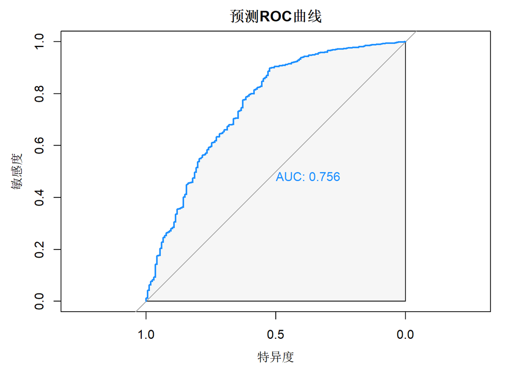

```r
par(family = "STXihei")
plot(roc_glm, col = "dodgerblue", print.auc = TRUE, auc.polygon = TRUE, auc.polygon.col = "#f6f6f6",
     main = "预测ROC曲线", xlim = c(1,0), xlab = "特异度", ylab = "敏感度")
```